# Factors

## Factors

A `factor` is a special `character` vector where the elements have pre-defined groups or ‘levels’. You can think of these as qualitative or categorical variables:

```r
x <- c("yellow", "red", "red", "blue", "yellow", "blue")
class(x)
```

```
## [1] "character"
```

```r
x_fact <- factor(x) # factor() is a function
class(x_fact)
```

```
## [1] "factor"
```

## Factors

Factors have **levels** (character types do not).

```r
x
```

```
## [1] "yellow" "red"    "red"    "blue"   "yellow" "blue"
```

```r
x_fact
```

```
## [1] yellow red    red    blue   yellow blue
## Levels: blue red yellow
```

Note that levels are, by default, in **alphanumerical** order.

## Factors - get the levels

Extract the levels of a `factor` vector using `levels()`:

```r
levels(x_fact)
```

```
## [1] "blue"   "red"    "yellow"
```

## Load the UFO data

```r
ufo <-
  read_csv("https://raw.githubusercontent.com/SISBID/Module1/gh-pages/data/ufo/ufo_data_complete.csv")
```

## Clean the names again

Using `janitor`.

```r
ufo <- clean_names(ufo)
glimpse(ufo)
```

```
## Rows: 88,875
## Columns: 11
## $ datetime           <chr> "10/10/1949 20:30", "10/10/1949 21:00", "10/10/1955…
## $ city               <chr> "san marcos", "lackland afb", "chester (uk/england)…
## $ state              <chr> "tx", "tx", NA, "tx", "hi", "tn", NA, "ct", "al", "…
## $ country            <chr> "us", NA, "gb", "us", "us", "us", "gb", "us", "us",…
## $ shape              <chr> "cylinder", "light", "circle", "circle", "light", "…
## $ duration_seconds   <dbl> 2700, 7200, 20, 20, 900, 300, 180, 1200, 180, 120, …
## $ duration_hours_min <chr> "45 minutes", "1-2 hrs", "20 seconds", "1/2 hour", …
## $ comments           <chr> "This event took place in early fall around 1949-50…
## $ date_posted        <chr> "4/27/2004", "12/16/2005", "1/21/2008", "1/17/2004"…
## $ latitude           <chr> "29.8830556", "29.38421", "53.2", "28.9783333", "21…
## $ longitude          <chr> "-97.9411111", "-98.581082", "-2.916667", "-96.6458…
```

## Preparing the data: separate into date and time

```r
ufo <- ufo |>separate(datetime,into = c("date", "time"), sep = " ")

glimpse(ufo)
```

```
## Rows: 88,875
## Columns: 12
## $ date               <chr> "10/10/1949", "10/10/1949", "10/10/1955", "10/10/19…
## $ time               <chr> "20:30", "21:00", "17:00", "21:00", "20:00", "19:00…
## $ city               <chr> "san marcos", "lackland afb", "chester (uk/england)…
## $ state              <chr> "tx", "tx", NA, "tx", "hi", "tn", NA, "ct", "al", "…
## $ country            <chr> "us", NA, "gb", "us", "us", "us", "gb", "us", "us",…
## $ shape              <chr> "cylinder", "light", "circle", "circle", "light", "…
## $ duration_seconds   <dbl> 2700, 7200, 20, 20, 900, 300, 180, 1200, 180, 120, …
## $ duration_hours_min <chr> "45 minutes", "1-2 hrs", "20 seconds", "1/2 hour", …
## $ comments           <chr> "This event took place in early fall around 1949-50…
## $ date_posted        <chr> "4/27/2004", "12/16/2005", "1/21/2008", "1/17/2004"…
## $ latitude           <chr> "29.8830556", "29.38421", "53.2", "28.9783333", "21…
## $ longitude          <chr> "-97.9411111", "-98.581082", "-2.916667", "-96.6458…
```

## Preparing the data: separate into hour and min

```r
ufo <- ufo |> separate(time, into= c("hour", "min"))

glimpse(ufo)
```

```
## Rows: 88,875
## Columns: 13
## $ date               <chr> "10/10/1949", "10/10/1949", "10/10/1955", "10/10/19…
## $ hour               <chr> "20", "21", "17", "21", "20", "19", "21", "23", "20…
## $ min                <chr> "30", "00", "00", "00", "00", "00", "00", "45", "00…
## $ city               <chr> "san marcos", "lackland afb", "chester (uk/england)…
## $ state              <chr> "tx", "tx", NA, "tx", "hi", "tn", NA, "ct", "al", "…
## $ country            <chr> "us", NA, "gb", "us", "us", "us", "gb", "us", "us",…
## $ shape              <chr> "cylinder", "light", "circle", "circle", "light", "…
## $ duration_seconds   <dbl> 2700, 7200, 20, 20, 900, 300, 180, 1200, 180, 120, …
## $ duration_hours_min <chr> "45 minutes", "1-2 hrs", "20 seconds", "1/2 hour", …
## $ comments           <chr> "This event took place in early fall around 1949-50…
## $ date_posted        <chr> "4/27/2004", "12/16/2005", "1/21/2008", "1/17/2004"…
## $ latitude           <chr> "29.8830556", "29.38421", "53.2", "28.9783333", "21…
## $ longitude          <chr> "-97.9411111", "-98.581082", "-2.916667", "-96.6458…
```

## Preparing the data: convert to numeric

```r
ufo <-ufo |> mutate(hour = as.numeric(hour), min = as.numeric(min))

glimpse(ufo)
```

```
## Rows: 88,875
## Columns: 13
## $ date               <chr> "10/10/1949", "10/10/1949", "10/10/1955", "10/10/19…
## $ hour               <dbl> 20, 21, 17, 21, 20, 19, 21, 23, 20, 21, 13, 19, 16,…
## $ min                <dbl> 30, 0, 0, 0, 0, 0, 0, 45, 0, 0, 0, 0, 0, 0, 0, 0, 3…
## $ city               <chr> "san marcos", "lackland afb", "chester (uk/england)…
## $ state              <chr> "tx", "tx", NA, "tx", "hi", "tn", NA, "ct", "al", "…
## $ country            <chr> "us", NA, "gb", "us", "us", "us", "gb", "us", "us",…
## $ shape              <chr> "cylinder", "light", "circle", "circle", "light", "…
## $ duration_seconds   <dbl> 2700, 7200, 20, 20, 900, 300, 180, 1200, 180, 120, …
## $ duration_hours_min <chr> "45 minutes", "1-2 hrs", "20 seconds", "1/2 hour", …
## $ comments           <chr> "This event took place in early fall around 1949-50…
## $ date_posted        <chr> "4/27/2004", "12/16/2005", "1/21/2008", "1/17/2004"…
## $ latitude           <chr> "29.8830556", "29.38421", "53.2", "28.9783333", "21…
## $ longitude          <chr> "-97.9411111", "-98.581082", "-2.916667", "-96.6458…
```

## Preparing the data: create timespan variable

```r
ufo <- ufo |>   mutate(timespan =
                    case_when(hour %in%c(18,19,20,21)~ "Evening",
                              hour >21 ~ "Night",
                              hour >=0 & hour <12 ~ "Morning",
                              hour >=12 & hour <18 ~ "Afternoon"))

ufo |> count(timespan)
```

```
## # A tibble: 4 × 2
##   timespan      n
##   <chr>     <int>
## 1 Afternoon 10828
## 2 Evening   32684
## 3 Morning   23517
## 4 Night     21846
```

## Check the output

You may have noticed that character data is arranged alphabetically.

```r
ufo |> count(timespan)
```

```
## # A tibble: 4 × 2
##   timespan      n
##   <chr>     <int>
## 1 Afternoon 10828
## 2 Evening   32684
## 3 Morning   23517
## 4 Night     21846
```

## Check the output

Character data is arranged alphabetically.

```r
ufo |> arrange(timespan) |> glimpse()
```

```
## Rows: 88,875
## Columns: 14
## $ date               <chr> "10/10/1955", "10/10/1968", "10/10/1970", "10/10/19…
## $ hour               <dbl> 17, 13, 16, 17, 17, 12, 12, 17, 15, 17, 16, 17, 13,…
## $ min                <dbl> 0, 0, 0, 0, 0, 0, 0, 0, 0, 5, 0, 0, 15, 30, 30, 40,…
## $ city               <chr> "chester (uk/england)", "hawthorne", "bellmore", "w…
## $ state              <chr> NA, "ca", "ny", "az", "sc", "tx", "mi", "fl", "tx",…
## $ country            <chr> "gb", "us", "us", NA, "us", "us", "us", "us", NA, N…
## $ shape              <chr> "circle", "circle", "disk", "light", "light", "othe…
## $ duration_seconds   <dbl> 20, 300, 1800, 120, 360, 30, 120, 3600, 3600, 0, 14…
## $ duration_hours_min <chr> "20 seconds", "5 min.", "30 min.", "2 min", "5-6 mi…
## $ comments           <chr> "Green/Orange circular disc over Chester&#44 Englan…
## $ date_posted        <chr> "1/21/2008", "10/31/2003", "5/11/2000", "2/18/2001"…
## $ latitude           <chr> "53.2", "33.9163889", "40.6686111", "0", "32.854444…
## $ longitude          <chr> "-2.916667", "-118.3516667", "-73.5275000", "0", "-…
## $ timespan           <chr> "Afternoon", "Afternoon", "Afternoon", "Afternoon",…
```

## Let’s plot the data

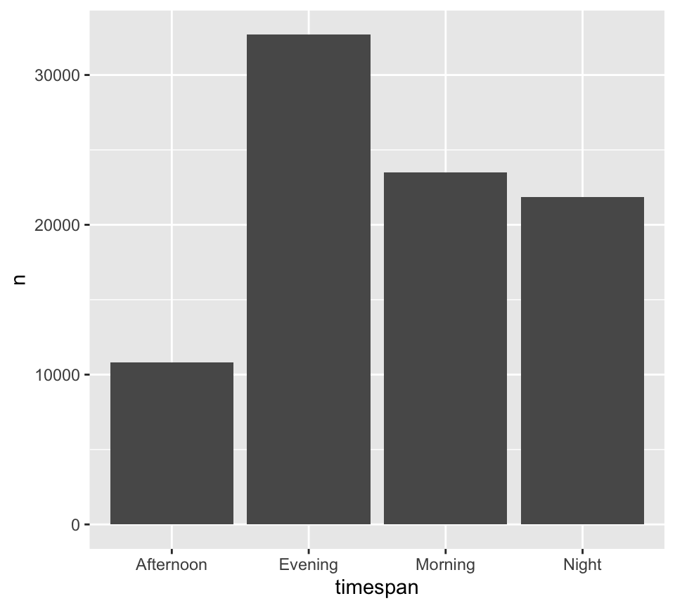

```r
count(ufo, timespan) |> ggplot(aes(x  = timespan, y = n)) + geom_col()
```

## Let’s try that again using factors

Currently `timespan` is class `character` but let’s change that to class `factor` which allows us to specify the levels or order of the values.

```r
ufo <- ufo |> mutate(timespan = factor(timespan, levels =
                  c("Morning", "Afternoon", "Evening", "Night")))
```

## Now let’s take a look at the data again

Factor data is arranged by level.

```r
ufo |> count(timespan)
```

```
## # A tibble: 4 × 2
##   timespan      n
##   <fct>     <int>
## 1 Morning   23517
## 2 Afternoon 10828
## 3 Evening   32684
## 4 Night     21846
```

Nice this is better!

## Now let’s take a look at the data again

Factor data is arranged by level.

```r
ufo |> arrange(timespan) |> glimpse()
```

```
## Rows: 88,875
## Columns: 14
## $ date               <chr> "10/10/1978", "10/10/1979", "10/10/1982", "10/10/19…
## $ hour               <dbl> 2, 0, 7, 5, 0, 3, 3, 2, 2, 3, 0, 3, 4, 6, 11, 3, 3,…
## $ min                <dbl> 0, 0, 0, 0, 0, 0, 20, 0, 30, 30, 1, 0, 0, 0, 0, 0, …
## $ city               <chr> "elmont", "poughkeepsie", "gisborne (new zealand)",…
## $ state              <chr> "ny", "ny", NA, "tx", "ca", NA, "mo", NA, "ca", "az…
## $ country            <chr> "us", "us", NA, "us", "us", NA, "us", NA, "us", "us…
## $ shape              <chr> "rectangle", "chevron", "disk", "circle", "disk", "…
## $ duration_seconds   <dbl> 300, 900, 120, 60, 300, 1200, 3, 15, 300, 15, 3600,…
## $ duration_hours_min <chr> "5min", "15 minutes", "2min", "1 minute", "approx 5…
## $ comments           <chr> "A memory I will never forget that happened meny ye…
## $ date_posted        <chr> "2/1/2007", "4/16/2005", "1/11/2002", "4/18/2012", …
## $ latitude           <chr> "40.7008333", "41.7002778", "-38.662334", "29.76305…
## $ longitude          <chr> "-73.7133333", "-73.9213889", "178.017649", "-95.36…
## $ timespan           <fct> Morning, Morning, Morning, Morning, Morning, Mornin…
```

## Let’s plot that again

The factor data is automatically plotted in the order we would like.

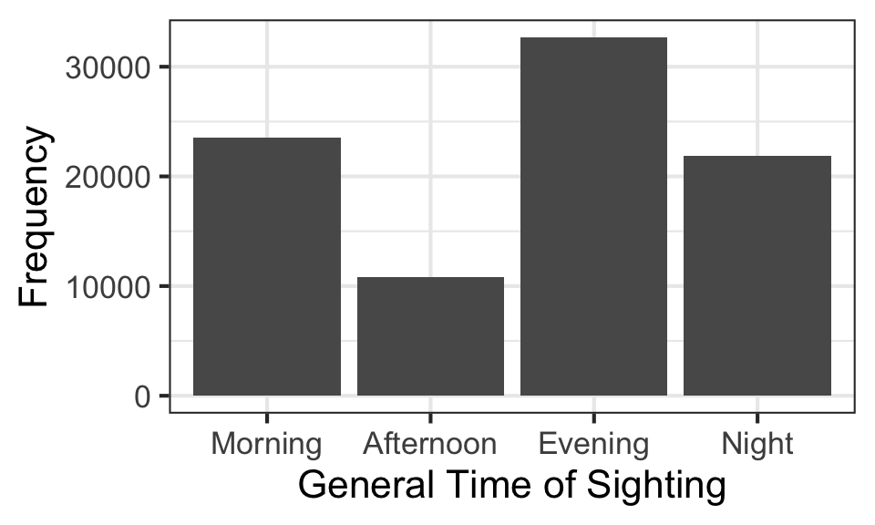

```r
count(ufo, timespan) |> ggplot(
  aes(x  = timespan, y = n)) +
  geom_col() +
  xlab("General Time of Sighting") + ylab("Frequency")+
  theme_bw(base_size = 16)
```

## `forcats` package

A package called `forcats` is really helpful for working with factors.

## `forcats` for ordering

We can order a factor by another variable by using the `fct_reorder()` function of the `forcats` package.

```r
fct_reorder({column getting changed}, {guiding column}, {summarizing function})
```

## `forcats` for ordering

Let’s reorder by another variable using `fct_reorder`.

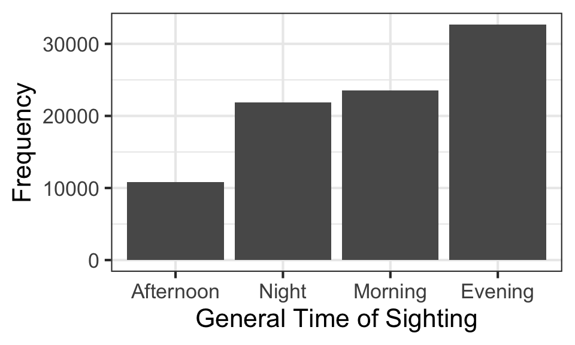

```r
count(ufo, timespan) |> ggplot(
  aes(x  = fct_reorder(timespan, n), y = n)) +
  geom_col() +
  xlab("General Time of Sighting") + ylab("Frequency")+
  theme_bw(base_size = 16)
```

This would be useful for identifying easily which timespan to focus on.

## forcats for ordering.. with `.desc =` argument

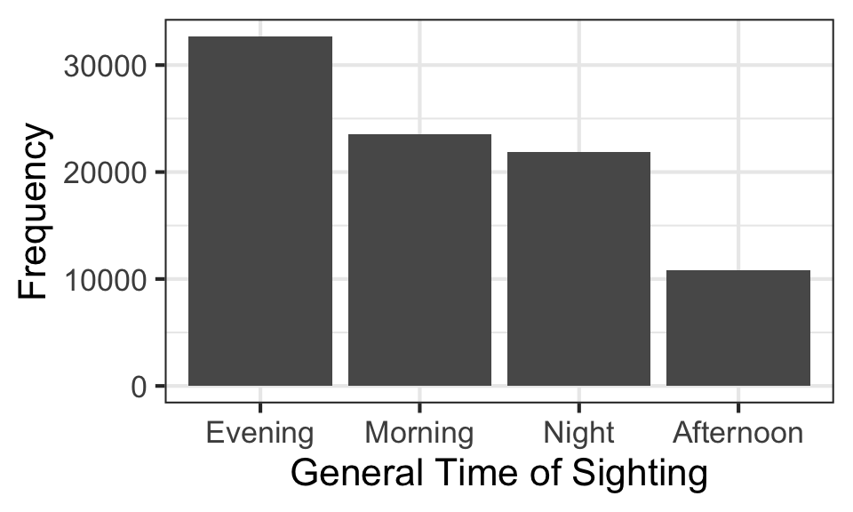

```r
count(ufo, timespan) |> ggplot(
  aes(x  = fct_reorder(timespan, n, .desc = TRUE), y = n)) +
  geom_col() +
  xlab("General Time of Sighting") + ylab("Frequency")+
  theme_bw(base_size = 16)
```

## GUT CHECK: Why use factors?

A. Meaningful ordering of text data

B. Automatic ordering or numeric data

C. More precise values

## Checking Proportions with `fct_count()`

The `fct_count()` function of the `forcats` package is helpful for checking that the proportions of each level for a factor are similar. Need the `prop = TRUE` argument otherwise just counts are reported.

```r
ufo |>
  pull(timespan) |>
  fct_count(prop = TRUE)
```

```
## # A tibble: 4 × 3
##   f             n     p
##   <fct>     <int> <dbl>
## 1 Morning   23517 0.265
## 2 Afternoon 10828 0.122
## 3 Evening   32684 0.368
## 4 Night     21846 0.246
```

## Summary

- the factor class allows us to have a different order from alphanumeric for categorical data
- we can change data to be a factor variable using `mutate` and a factor creating function like `factor()` (alphabetical order by default)
- with `factor()` we can specify the levels with the `levels` argument if we want a specific order
- the `fct_reorder({variable_to_reorder}, {variable_to_order_by}, {summary function})` helps us reorder a variable by the values of another variable
- arranging, tabulating, and plotting the data will reflect the new order

## Lab

🏠 [Class Website](https://jhudatascience.org/intro_to_r/)  
💻 [Lab](https://sisbid.github.io/Data-Wrangling/13_Factors/lab/factors-lab.Rmd)